# PS8_JTung

```r
real <- as.numeric(as_tibble(voter_split$test)$vote96)
E1 <- mean(as.numeric(real != median(real)))
E2 <- 0.3015

PRE <- (E1 - E2) / E1
PRE
```

```
## [1] 0.1006538
```

Radial Kernal

```r
# set random seed
set.seed(1234)

voter_rad_tune <- tune(svm, vote96 ~ ., data = as_tibble(voter_split$train),
                    kernel = "radial",
                    range = list(cost = c(.001, .01, .1, 1, 5, 10, 100)))

summary(voter_rad_tune)
```

```
##
## Parameter tuning of 'svm':
##
## - sampling method: 10-fold cross validation
##
## - best parameters:
##  cost
##     1
##
## - best performance: 0.2917344
##
## - Detailed performance results:
##    cost     error dispersion
## 1 1e-03 0.3199488 0.04400821
## 2 1e-02 0.3199488 0.04400821
## 3 1e-01 0.3064589 0.04453183
## 4 1e+00 0.2917344 0.03049168
## 5 5e+00 0.2954231 0.03999776
## 6 1e+01 0.2929840 0.03390399
## 7 1e+02 0.3199036 0.03130218
```

```r
voter_rad1 <- voter_rad_tune$best.model
summary(voter_rad1)
```

```
##
## Call:
## best.tune(method = svm, train.x = vote96 ~ ., data = as_tibble(voter_split$train),
##     ranges = list(cost = c(0.001, 0.01, 0.1, 1, 5, 10, 100)),
##     kernel = "radial")
##
##
## Parameters:
##    SVM-Type:  C-classification
##  SVM-Kernel:  radial
##        cost:  1
##       gamma:  0.125
##
## Number of Support Vectors:  509
##
##  ( 265 244 )
##
##
## Number of Classes:  2
##
## Levels:
##  0 1
```

```r
fitted3 <- predict(voter_rad1, as_tibble(voter_split$test), decision.values = TRUE) %>%
  attributes


roc_3 <- roc(as_tibble(voter_split$test)$vote96, fitted3$decision.values)
auc(roc_3)
```

```
## Area under the curve: 0.7349
```

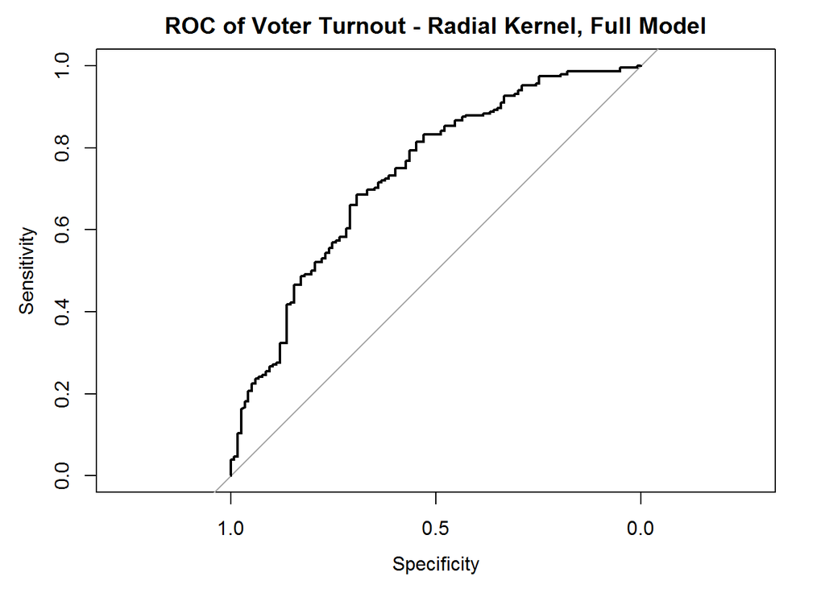

```r
plot(roc_3, main = "ROC of Voter Turnout - Radial Kernel, Full Model")
```

```r
real <- as.numeric(as_tibble(voter_split$test)$vote96)
E1 <- mean(as.numeric(real != median(real)))
E2 <- 0.2917

PRE <- (E1 - E2) / E1
PRE
```

```
## [1] 0.1298863
```

Radial kernal with education, age, mental health sum, income data predictors only

```r
# set random seed
set.seed(1234)

voter_rad2_tune <- tune(svm, vote96 ~  educ + age + mhealth_sum + inc10, data = as_tibble(voter_split$train),
                    kernel = "radial",
                    range = list(cost = c(.001, .01, .1, 1, 5, 10, 100)))

summary(voter_rad2_tune)
```

```
##
## Parameter tuning of 'svm':
##
## - sampling method: 10-fold cross validation
##
## - best parameters:
##  cost
##     5
##
## - best performance: 0.2967179
##
## - Detailed performance results:
##    cost     error dispersion
## 1 1e-03 0.3199488 0.04400821
## 2 1e-02 0.3199488 0.04400821
## 3 1e-01 0.3088979 0.03874420
## 4 1e+00 0.2978922 0.02992651
## 5 5e+00 0.2967179 0.04785661
## 6 1e+01 0.2979524 0.04629471
## 7 1e+02 0.2992020 0.04499354
```

```r
voter_rad2 <- voter_rad2_tune$best.model
summary(voter_rad2)
```

```
##
## Call:
## best.tune(method = svm, train.x = vote96 ~ educ + age + mhealth_sum +
##     inc10, data = as_tibble(voter_split$train), ranges = list(cost = c(0.001,
##     0.01, 0.1, 1, 5, 10, 100)), kernel = "radial")
##
##
## Parameters:
##    SVM-Type:  C-classification
##  SVM-Kernel:  radial
##        cost:  5
##       gamma:  0.25
##
## Number of Support Vectors:  484
##
##  ( 250 234 )
##
##
## Number of Classes:  2
##
## Levels:
##  0 1
```

```r
fitted4 <- predict(voter_rad2, as_tibble(voter_split$test), decision.values = TRUE) %>%
  attributes


roc_4 <- roc(as_tibble(voter_split$test)$vote96, fitted4$decision.values)
auc(roc_4)
```

```
## Area under the curve: 0.7032
```

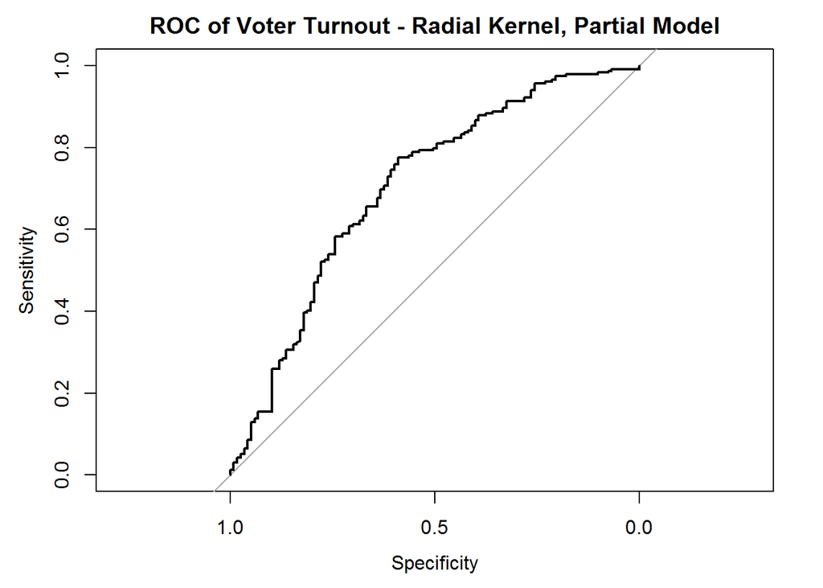

```r
plot(roc_4, main = "ROC of Voter Turnout - Radial Kernel, Partial Model")
```

```r
real <- as.numeric(as_tibble(voter_split$test)$vote96)
E1 <- mean(as.numeric(real != median(real)))
E2 <- 0.2967

PRE <- (E1 - E2) / E1
PRE
```

```
## [1] 0.1149718
```

Polynomial Kernal with education, age, mental health sum, income data predictors only

```r
# set random seed
set.seed(1234)

voter_pol2_tune <- tune(svm, vote96 ~ educ + age + mhealth_sum + inc10, data = as_tibble(voter_split$train),
                    kernel = "polynomial",
                    range = list(cost = c(.001, .01, .1, 1, 5, 10, 100)))

summary(voter_pol2_tune)
```

```
##
## Parameter tuning of 'svm':
##
## - sampling method: 10-fold cross validation
##
## - best parameters:
##  cost
##     5
##
## - best performance: 0.2954833
##
## - Detailed performance results:
##    cost     error dispersion
## 1 1e-03 0.3199488 0.04400821
## 2 1e-02 0.3211984 0.05031666
## 3 1e-01 0.3065041 0.04811485
## 4 1e+00 0.2966877 0.04792033
## 5 5e+00 0.2954833 0.04655177
## 6 1e+01 0.2954833 0.04655177
## 7 1e+02 0.2954833 0.04655177
```

```r
voter_pol2 <- voter_pol2_tune$best.model
summary(voter_pol2)
```

```
##
## Call:
## best.tune(method = svm, train.x = vote96 ~ educ + age + mhealth_sum +
##     inc10, data = as_tibble(voter_split$train), ranges = list(cost = c(0.001,
##     0.01, 0.1, 1, 5, 10, 100)), kernel = "polynomial")
##
##
## Parameters:
##    SVM-Type:  C-classification
##  SVM-Kernel:  polynomial
##        cost:  5
##      degree:  3
##       gamma:  0.25
##      coef.0:  0
##
## Number of Support Vectors:  492
##
##  ( 247 245 )
##
##
## Number of Classes:  2
##
## Levels:
##  0 1
```

```r
fitted5 <- predict(voter_pol2, as_tibble(voter_split$test), decision.values = TRUE) %>%
  attributes


roc_5 <- roc(as_tibble(voter_split$test)$vote96, fitted5$decision.values)
auc(roc_5)
```

```
## Area under the curve: 0.7537
```

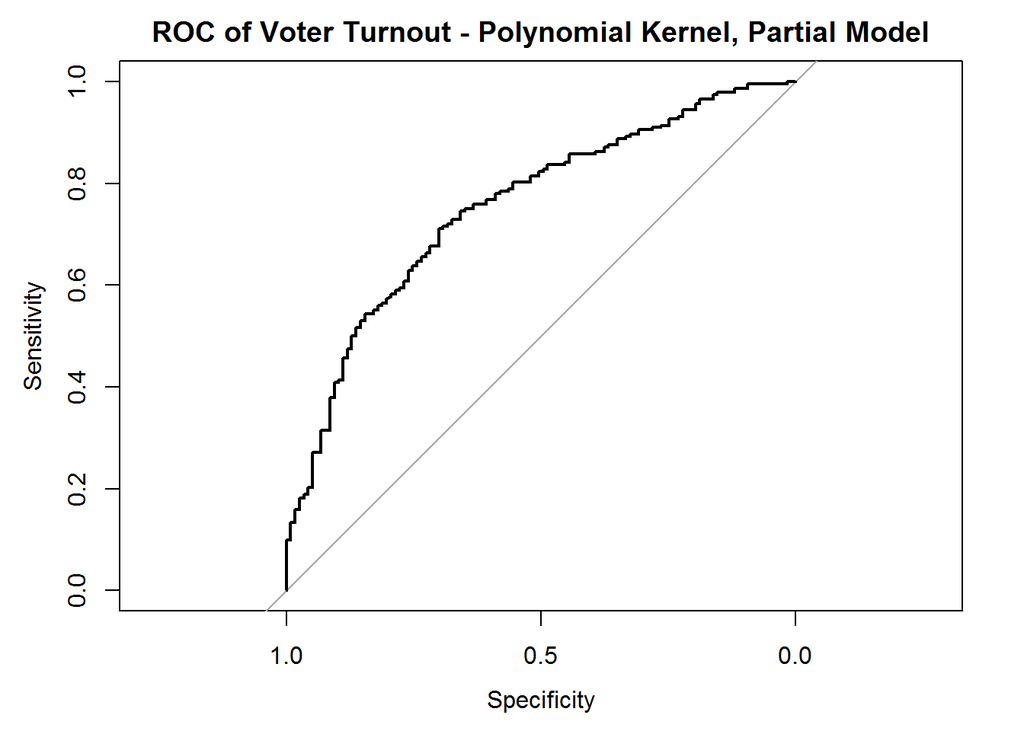

```r
plot(roc_5, main = "ROC of Voter Turnout - Polynomial Kernel, Partial Model")
```

```r
real <- as.numeric(as_tibble(voter_split$test)$vote96)
E1 <- mean(as.numeric(real != median(real)))
E2 <- 0.2955

PRE <- (E1 - E2) / E1
PRE
```

```
## [1] 0.1185513
```

Compare the 5 ROC curves

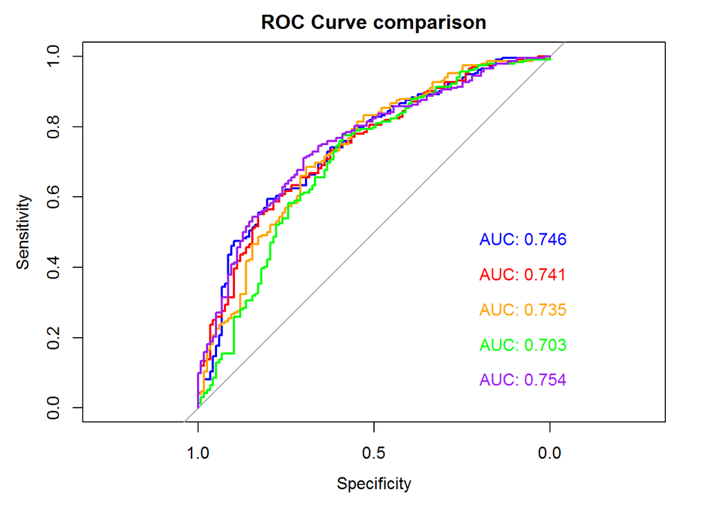

```r
plot(roc_1, print.auc = TRUE, col = "blue", print.auc.x = .2, main = "ROC Curve comparison")
plot(roc_2, print.auc = TRUE, col = "red", print.auc.x = .2, print.auc.y = .4, add = TRUE)
plot(roc_3, print.auc = TRUE, col = "orange", print.auc.x = .2, print.auc.y = .3, add = TRUE)
plot(roc_4, print.auc = TRUE, col = "green", print.auc.x = .2, print.auc.y = .2, add = TRUE)
plot(roc_5, print.auc = TRUE, col = "purple", print.auc.x = .2, print.auc.y = .1, add = TRUE)
```

Part 3: O.J. Simpson

1. What is the relationship between race and belief of OJ Simpson’s guilt? Develop a robust statistical learning model and use this model to explain the impact of an individual’s race on their beliefs about OJ Simpson’s guilt.

The best way to explain relationships between predictor(s) and a response is to run non-tree regression methods. Because the respons (belief in OJ Simpson’s guilt) takes on either values of 0 or 1, the most appropriate none-tree regression method is likely the logistic regression approach. The logistic regression approach gives us the probability of a given outcome occurring; we set a threshhold (0.5) to flag the limit at which a probability should register as 0 or 1. First, we’ll clean up the data so that the race column reflects options for black (B), hispanic (H) or other (O). Then we’ll run the logistic regression with the Bernoulli distrbution and the logit function as our link function using a training set (70% of the data), and test model accuracy using the remaining 30% of data as a test set.

The resultant model summary, model accuracy, PRE and AUC are reported below. Since we are using a 3-category predictor variable (race = B, O or H), the glm function estimates the model holding one category constant as a baseline: in this case, the race Black was used as baseline. To make the coefficients easier to interpret, we have exponentiated the coefficients so that they correspond to “relative risk” or “odds”. This tells us that being hispanic versus black will increase the odds that the respondent believes OJ is guilty by 12.58 poonts, and that being non-hispanic and non-black will increase the odds that the respondent believes OJ is guildy by 21.65 points. In other words, the odds are greatest that a respondent believes OJ is innocent if he/she is black. Furthermore, we can see that race is indeed a significant predictor of belief in OJ’s guilt: both the raceH and raceO predictors have p-values that are fall smaller than the standard 0.05 p-value limit.

This model did quite well on the test set, with an observed model accuracy of ~83%, AUC of 0.7436 and PRE (improvement over the useless classifier’s error) of 43.4%. Obtaining such predictive performance from a single predictor variable indicates that race is indeed a good predictor of the response and highly correlated to the response.

Get the data and recode a race column as O (other), H (hispanic), B (black). Then split the data into a training/test set.

```r
# set the seed
set.seed(1234)

# get data
simpson <- read_csv("data/simpson.csv")
simpson$race <- with(simpson, ifelse(black == 0 & hispanic == 0,"O",ifelse(black==0 & hispanic == 1, "H","B")))

# split the data into training/test set
simpson_split <- resample_partition(simpson, c(test = 0.3, train = 0.7))
simpson_train <- simpson_split$train %>%
  tbl_df()
simpson_test <- simpson_split$test %>%
  tbl_df()
```

Run the logistic regression on predictor “race”

```r
# model race in logistic regression
race_glm <- glm(guilt ~ race, data = simpson_split$train, family = binomial)
summary(race_glm)
```

```
##
## Call:
## glm(formula = guilt ~ race, family = binomial, data = simpson_split$train)
##
## Deviance Residuals:
##     Min       1Q   Median       3Q      Max
## -1.8265  -0.6021   0.6465   0.6465   1.8959
##
## Coefficients:
##             Estimate Std. Error z value Pr(>|z|)
## (Intercept)  -1.6159     0.1966  -8.217  < 2e-16 ***
## raceH         2.5322     0.3412   7.420 1.17e-13 ***
## raceO         3.0750     0.2180  14.104  < 2e-16 ***
## ---
## Signif. codes:  0 '***' 0.001 '**' 0.01 '*' 0.05 '.' 0.1 ' ' 1
##
## (Dispersion parameter for binomial family taken to be 1)
##
##     Null deviance: 1233.12  on 986  degrees of freedom
## Residual deviance:  957.05  on 984  degrees of freedom
##   (112 observations deleted due to missingness)
## AIC: 963.05
##
## Number of Fisher Scoring iterations: 4
```

```r
# function to convert log odds output of the binomial glm to probabilities
logit2prob <- function(x){
  exp(x) / (1 + exp(x))
}

# get probabilities from predicted log odds for our test set
accuracy <- simpson_test %>%
  add_predictions(race_glm) %>%
  mutate(pred = logit2prob(pred),
         prob = as.numeric(pred > .5))

# evaluate the model accuracy
model_accuracy = mean(accuracy$guilt == accuracy$prob, na.rm = TRUE)

auc <- auc(accuracy$guilt, accuracy$prob)

real <- na.omit(as.numeric(as_tibble(simpson_split$test)$guilt))
E1 <- mean(as.numeric(real != median(real)))
E2 <- 1 - model_accuracy
PRE <- (E1 - E2) / E1

model_accuracy
```

```
## [1] 0.8298368
```

```r
auc
```

```
## Area under the curve: 0.7436
```

```r
PRE
```

```
## [1] 0.4341085
```

```r
coeff <- exp(coef(race_glm))
coeff
```

```
## (Intercept)       raceH       raceO
##   0.1987179  12.5806452  21.6495707
```

2. How can you predict whether individuals believe OJ Simpson to be guilty of these murders? Develop a robust statistical learning model to predict whether individuals believe OJ Simpson to be either probably guilty or probably not guilty and demonstrate the of this model using methods we have discussed in class.

Tree-based methods are especially good for predictive performance and are easily interpretable. As a result, for this step, we will use explore tree-based methods to generate a robust predictive model. A standard decision tree created using default parameters was first tried with all possible predictors. The result was a 3 terminal node tree with age and black as the internal nodes over each split occurred. This suggested to me that the significance of variable “black” and age are highly important such that they greatly minimize RSS (residual sum of squares) for a given split. The performance of this model is quite good, with an AUC of 0.733 and a PRE (reduction in the error from the useless classifier) of ~42%. This is not up to par with the logistic regression model above, but approaches its performance.

Given the success of this model, a second random forest approach was tried. Given the strong weight that the predictor “black” has on the response, we hoped that the random forest method might help us find a wider diversity of “less squentially obvious” reductions in RSS in the construction of decision trees that might result in greater predicting power of our model.

Reimport data with new characteristics

```r
tree_oj <- read_csv('data/simpson.csv') %>%
  na.omit %>%
  mutate(guilt = factor(guilt),
         dem = factor(dem),
         rep = factor(rep),
         ind = factor(ind),
         female = factor(female),
         black = factor(black),
         hispanic = factor(hispanic),
         educ = factor(educ))
set.seed(1234)
oj_split <- resample_partition(tree_oj, c(test = .3, train = .7))
```

Create Standard Decision Tree

```r
# Create decision tree
simp_tree1 <- tree(guilt ~ ., data = as_tibble(oj_split$train))
simp_tree1
```

```
## node), split, n, deviance, yval, (yprob)
##       * denotes terminal node
##
## 1) root 992 1229.0 1 ( 0.3105 0.6895 )
##   2) black: 0 805  780.1 1 ( 0.1888 0.8112 )
##     4) age < 37.5 314  362.7 1 ( 0.2643 0.7357 ) *
##     5) age > 37.5 491  398.6 1 ( 0.1405 0.8595 ) *
##   3) black: 1 187  168.0 0 ( 0.8342 0.1658 ) *
```

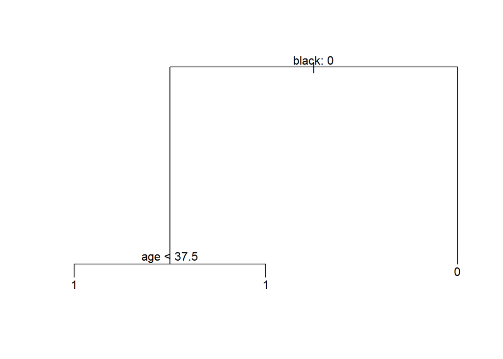

```r
plot(simp_tree1)
text(simp_tree1, pretty = 0)
```

```r
simp_fitted1 <- predict(simp_tree1, as_tibble(oj_split$test), type = 'class')
```

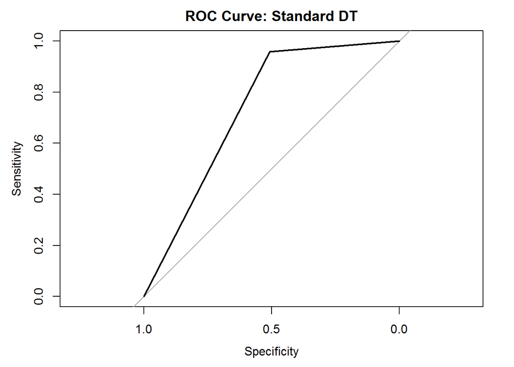

```r
simp_err1 <- mean(as_tibble(oj_split$test)$guilt != simp_fitted1)

roc_simp1 <- roc(as.numeric(as_tibble(oj_split$test)$guilt), as.numeric(simp_fitted1))
plot(roc_simp1, main="ROC Curve: Standard DT")
```

```r
auc(roc_simp1)
```

```
## Area under the curve: 0.733
```

```r
simp_err1
```

```
## [1] 0.1839623
```

```r
simp_testerr1 <- tree_errate(simp_tree1, oj_split$test)
simp_testerr1
```

```
## [1] 0.1839623
```

```r
real <- as.numeric(as_tibble(oj_split$test)$guilt)
E1 <- mean(as.numeric(real != median(real)))
E2 <- simp_err1

PRE <- (E1 - E2) / E1
PRE
```

```
## [1] 0.4179104
```

Use Random Forest Approach

```r
# set the random seed
set.seed(1234)

simp_tree2 <- randomForest(guilt ~  female + age + black + hispanic + educ, data = na.omit(as_tibble(oj_split$train)))
simp_tree2
```

```
##
## Call:
##  randomForest(formula = guilt ~ female + age + black + hispanic +      educ, data = na.omit(as_tibble(oj_split$train)))
##                Type of random forest: classification
##                      Number of trees: 500
## No. of variables tried at each split: 2
##
##         OOB estimate of  error rate: 19.25%
## Confusion matrix:
##     0   1 class.error
## 0 157 151  0.49025974
## 1  40 644  0.05847953
```

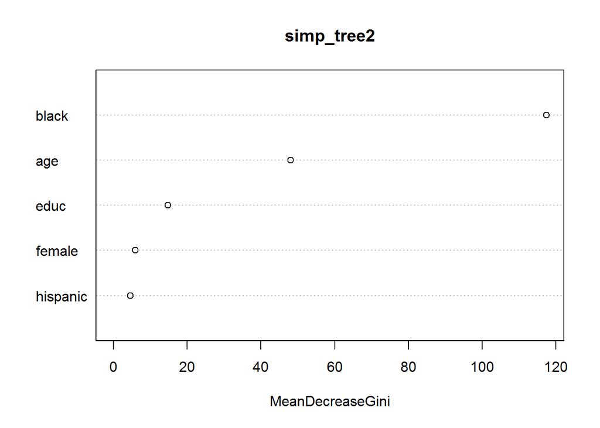

```r
varImpPlot(simp_tree2)
```

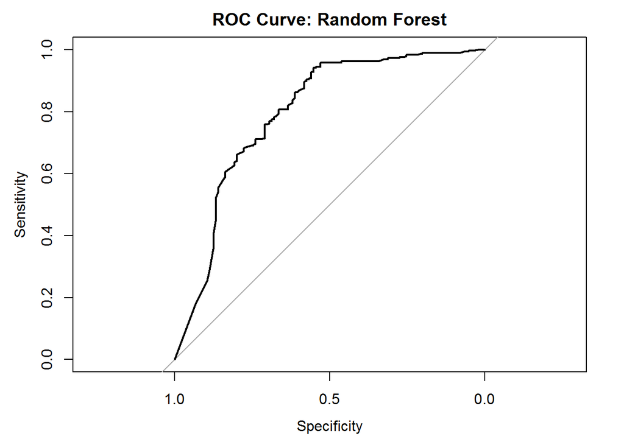

```r
fitted2 <- predict(simp_tree2, as_tibble(oj_split$test), type = "prob")[,2]
tree_err2 <- mean(as_tibble(oj_split$test)$guilt != fitted2)

roc_simp2 <- roc(as_tibble(oj_split$test)$guilt, fitted2)
plot(roc_simp2, main="ROC Curve: Random Forest")
```

```r
auc(roc_simp2)
```

```
## Area under the curve: 0.7952
```

```r
simp_testerr2 <- tree_errate(simp_tree2, oj_split$test)
tree_err2
```

```
## [1] 0.8773585
```

```r
simp_testerr2
```

```
## [1] 0.1768868
```

```r
real <- as.numeric(as_tibble(oj_split$test)$guilt)
E1 <- mean(as.numeric(real != median(real)))
E2 <- simp_testerr2

PRE <- (E1 - E2) / E1
PRE
```

```
## [1] 0.4402985
```